# Transaction Feature Exploration

Tom And Nick

20 November 2017

# Data Read

First read in the data and test variable types

### Joining in Delivery Keys

Join delivery key data on the delivery type field. This will need renaming as they are labelled differently in each dataset. From here, the data is grouped and counted.

```r
trans_del <- trans %>%
  left_join(del_key) %>%
  group_by(Name) %>%
  summarise(n = n())
```

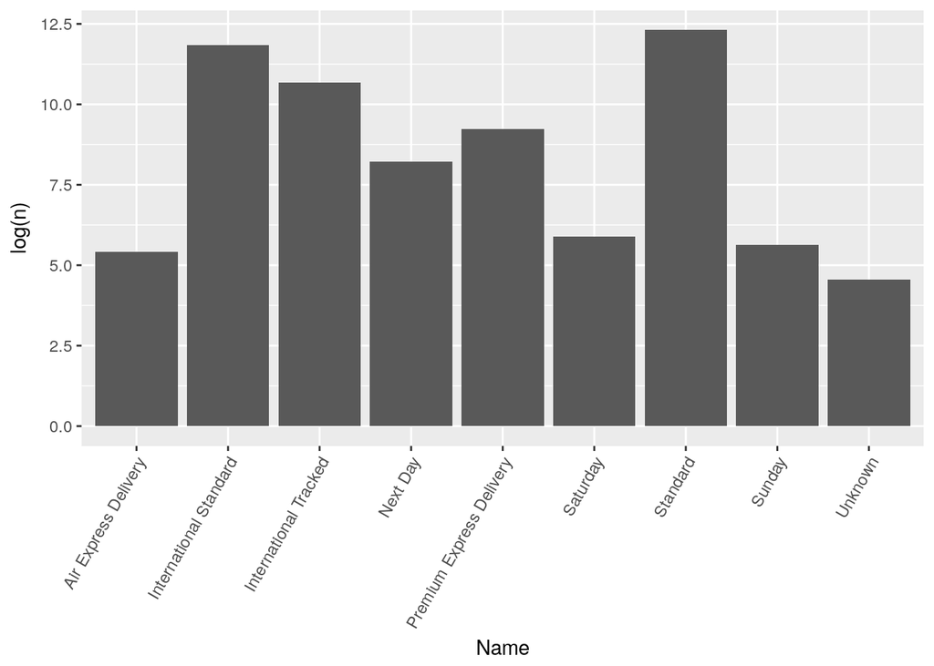

```r
p <- trans_del %>%
  ggplot(aes(x = Name, y = log(n))) +
  geom_col() +
  theme(axis.text.x = element_text(angle = 60, hjust = 1))

plot(p)
```

Features can then be engineered to determine the following:

- Potential Occupation
- Package Destination
- Delivery Urgency

```r
del_features <- data.frame(Name = as.character(unique(trans_del$Name)),
                           destination = c(rep("int", 3), rep("dom", 6)),
                           priority = c("priority", rep("slow", 2), rep("priority", 2), rep("slow", 4)),
                           occupation = c(rep("unknown", 5), "working", "unknown", "working", "unknown"))

del_join <- del_key %>%
  left_join(del_features)
```

### Who’s a reliable customer?

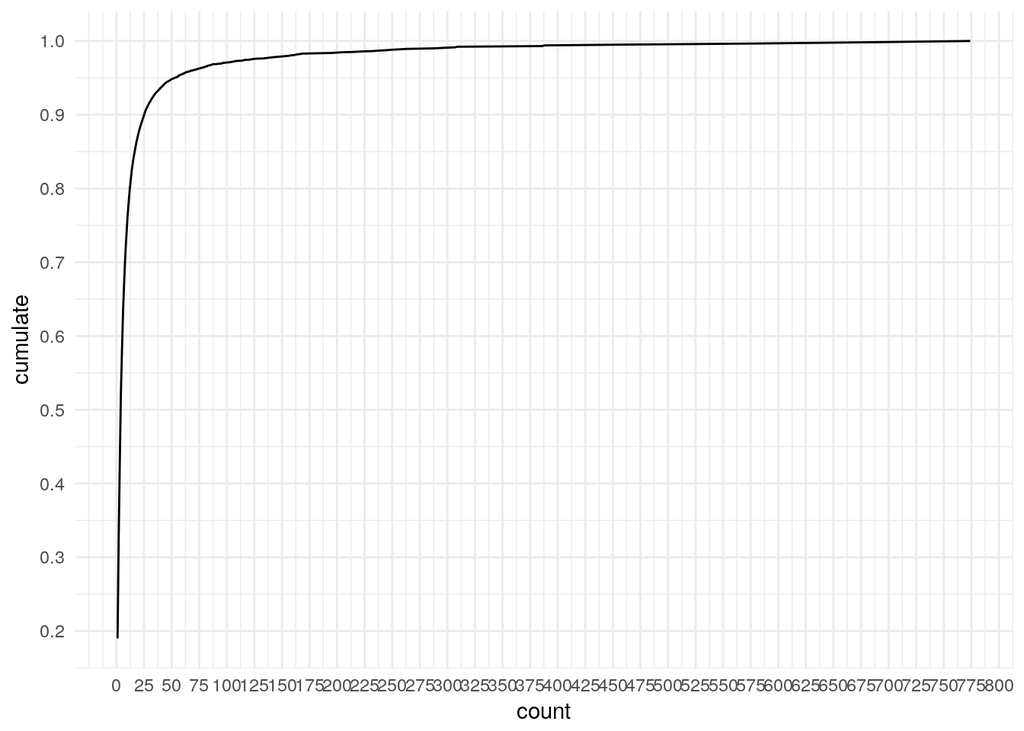

```r
customers <- trans %>%
  group_by(Account_Key) %>%
  mutate(count = n()) %>%
  group_by(count) %>%
  summarise(n = n())

customers$prop <- customers$n/dim(trans)[1]
customers$cumulate <- cumsum(customers$prop)
customers %>%
  ggplot(aes(x = count, y = cumulate)) +
  geom_line() +
  scale_x_continuous(breaks = seq(0, 800, by = 25)) +
  scale_y_continuous(breaks = seq(0, 800, by = 0.1)) +
  theme_minimal()
```

### Looking back at the customer’s payment validity history

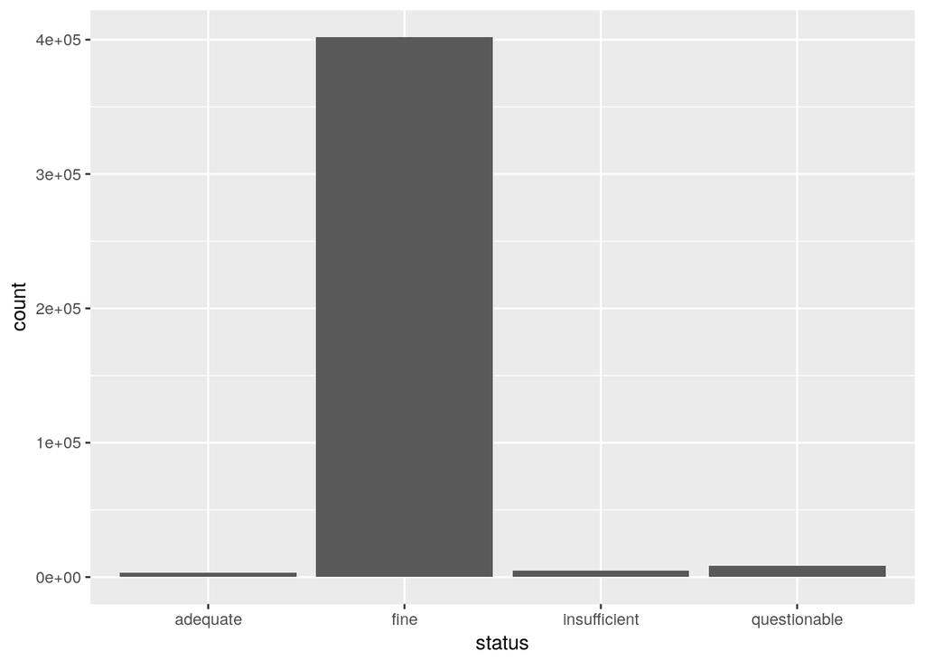

```r
payment_hists <- trans %>%
  group_by(Account_Key) %>%
  mutate(pay_key_num = as.numeric(Order_Payment_Status_Key),
         num_valid = length(which(pay_key_num == 0)),
         count = n(),
         prop = num_valid/count,
         status = ifelse(prop <= 0.25 & count > 2, "questionable",
                         ifelse(prop <= 0.25 & count <= 2, "insufficient",
                                ifelse(prop > 0.25 & prop < 0.75, "adequate", "fine"))))

payment_hists %>%
  ggplot(aes(x = status)) +
  geom_bar(stat = "count")
```

### Proportion of Cancelled Items, by item type

```r
cancelled_items <- trans %>%
  group_by(Category_Level_3, Category_Level_2) %>%
  mutate(canc_prop = ifelse(Cancelled_Qty == 0, 0, Cancelled_Qty/Ordered_Qty))
```

From doing this is appears that row number 259450 is an error, with two items being cancelled, but only one ordered. Odd…

### Shipping and Billing Mismatch

If the billing and shipping postcodes do not match, fraud is possible.

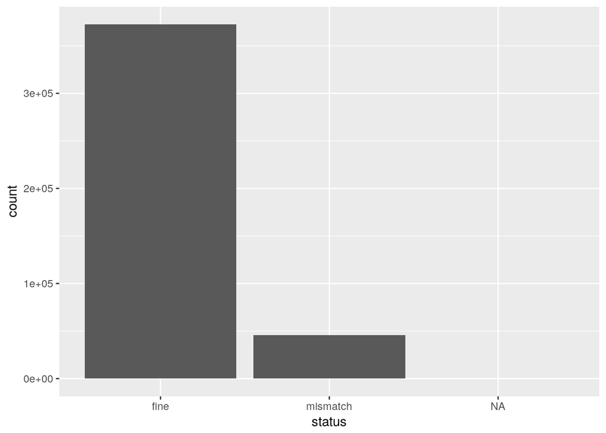

```r
bill_ship_match <- trans %>%
  mutate(status = ifelse(Postcode_Billing_Address != Postcode_Shipping_Address, "mismatch", "fine"))

bill_ship_match %>%
  ggplot(aes(x = status)) +
  geom_bar(stat = "count")
```

```r
table(bill_ship_match$status)
```

```
##
##     fine mismatch
##   372594    45647
```

### Reverse IP address

Using [this link](https://db-ip.com/db/), we can trace the IP back to obtain city. **Is fraud more prevalent in certain location**? This is likely to be easier than wrangling with postcodes and city mistypes

### Cancelled Date Key

Could investigate if cancelations occur on certain days more than others.

### Order Date

To be obtained:

- Season
- Weekday/Weekend
- Day of week
- Public Holiday

### Locale

From here, the language from where the order originated from.

### Payment Provider Key

Ask Konstantinos - do they regard different providers differently.

### Charge Price

Ask/find journal article. Is fraud more prevalent in lower to mid priced items? Logic would assume so…

### Un-engineerable Columns

Payment method lookup contains the payment type and the type of card (credit/debit). Both useful, but cannot think of too much additional insight to be extracted.